# Practical Machine Learning Project

Mayank Singh

## Summary

The study aims to predict the manner in which exercises were carried out in the correct manner using data from devices such as Jawbone Up, Nike FuelBand, and Fitbit. The predictions would help measure the how in the personal activity space.

The steps in the analysis include:

1. Preprocessing and transforming the data used for the analysis.
2. Exploratory analysis on the data find out relevant variables and patterns that may help in subsequent study.
3. Identifying an ideal model suited to the problem based on the exploratory analysis.
4. Evaluating the model to find out the best fit.
5. Predicting outcomes on the out of sample data.

### Preprocessing

Loading the data:

```r
training <- read.csv("pml-training.csv")
testing <- read.csv("pml-testing.csv")
```

Reading in the dimensions:

```r
dim(training)
```

```
## [1] 19622   160
```

```r
dim(testing)
```

```
## [1]  20 160
```

The model has 160 variables.

Removing variables that do not contain much information (more than 25% rows are NAs) and variables we will not use (Time Stamp variables):

```r
col_to_rem <- which(colSums(is.na(training) | training == "" | training == "#DIV/0!") >
    nrow(training) * 0.25)
timestamp_cols <- grep("timestamp", names(training))

training_new <- training[, -col_to_rem]
testing_new <- testing[, -col_to_rem]

training_new <- training_new[, -c(1, timestamp_cols)]
training_new <- training_new[, -c(1, 2, 3)]

testing_new <- testing_new[, -c(1, timestamp_cols)]
testing_new <- testing_new[, -c(1, 2, 3)]
```

We are now left with 53 variables.

Convert all numerical variables to integers variables for appropriate use in the subsequent process.

```r
classelabs <- levels(training_new$classe)
training_new <- data.frame(data.matrix(training_new))
training_new$classe <- factor(training_new$classe, labels = classelabs)
```

Splitting the data into Training and Testing set:

```r
library(caret)
classe_num <- which(names(training_new) == "classe")
inTrain <- createDataPartition(y = training_new$classe, p = 0.7, list = F)
training_new_train <- training_new[inTrain, ]
training_new_test <- training_new[-inTrain, ]
```

## Exploratory Data Analysis

Identifying highly correlated variables

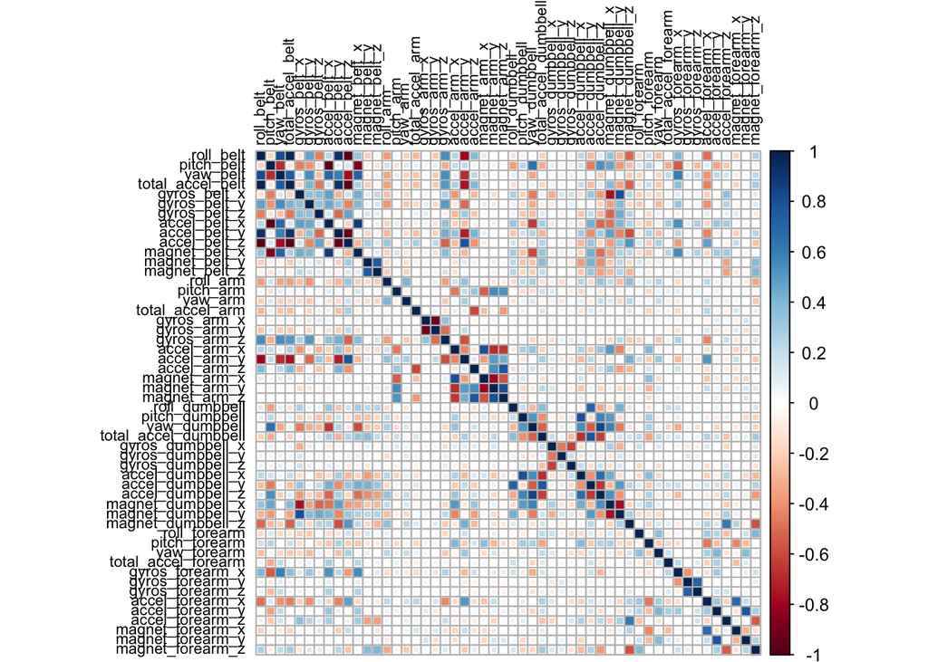

```r
library(caret)
library(ggplot2)
library(corrplot)

cor_matrix <- cor(training_new_test[, -classe_num])
corrplot(cor_matrix, method = "square", tl.cex = 0.7, tl.col = "black")
```

We can see some variables are highly correlated with each other.

Removing the features which are highly correlated using PCA.

```r
high_cor <- findCorrelation(cor_matrix, cutoff = 0.9, exact = T)
cols_rem <- c(high_cor, classe_num)

PCA_preprocess <- preProcess(training_new_train[, -cols_rem], method = "pca")

training_new_train_pca <- predict(PCA_preprocess, training_new_train[-cols_rem])
training_new_test_pca <- predict(PCA_preprocess, training_new_test[-cols_rem])

testing_new_pca <- predict(PCA_preprocess, testing_new[, -c(classe_num, cols_rem)])
```

## Identifying the Ideal Model

We will run the analysis on three data sets:

1. The original train-test split we created with all the variables.
2. The train-test split without the highly correlated variables
3. The train-test split with PCA components

Then we will evaluate the results on the in-sample testing set and choose the best model.

We will be using a *Random Forest Model* with 100 trees for this Analysis.

```r
library(randomForest)
ntrees <- 100

# complete data
RF_complete_data <- randomForest(x = training_new_train[, -classe_num], y = training_new_train$classe,
    xtest = training_new_test[, -classe_num], ytest = training_new_test$classe,
    ntree = ntrees, keep.forest = T)

# without highly correlated variables
RF_uncorrelated <- randomForest(x = training_new_train[, -c(classe_num, cols_rem)],
    y = training_new_train$classe, xtest = training_new_test[, -c(classe_num,
        cols_rem)], ytest = training_new_test$classe, ntree = ntrees, keep.forest = T)

# with the PCA components
RF_PCA_comps <- randomForest(x = training_new_train_pca[, -classe_num], y = training_new_train$classe,
    xtest = training_new_test_pca[, -classe_num], ytest = training_new_test$classe,
    ntree = ntrees, keep.forest = T)
```

## Predictions on Out of Sample Data

Lets predict on out of sample data using the RF_complete_data model:

```r
predictions <- predict(RF_complete_data, testing_new)
```

The predictions for the 20 out of sample rows are:

B, A, B, A, A, E, D, B, A, A, B, C, B, A, E, E, A, B, B, B

## Conclusion

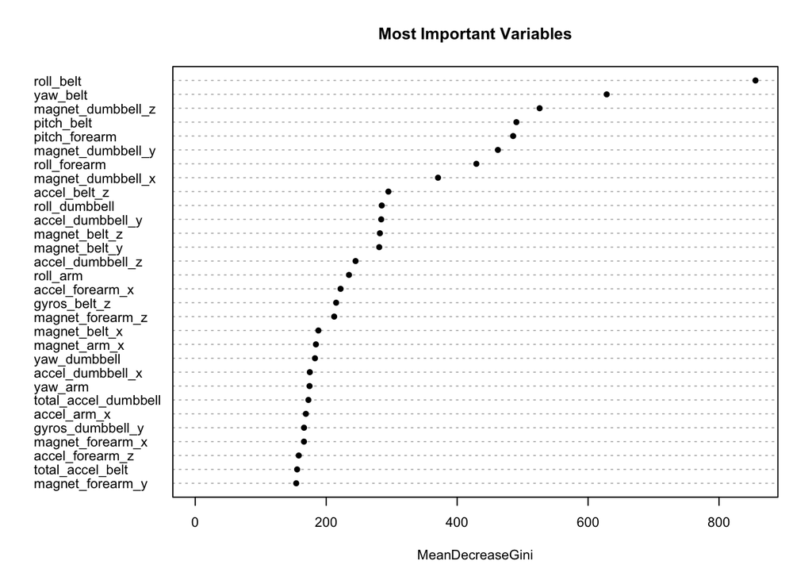

```r
varImpPlot(RF_complete_data, cex = 0.7, pch = 16, main = "Most Important Variables")
```